# Reproducible Reasearch- Course Project I

Himanshu Patil

8/11/2020

Setting global option to turn warnings off

```r
knitr::opts_chunk$set(warning=FALSE)
```

*Q.1 Code for reading in the dataset and/or processing the data*

```r
activity.data <- read.csv("activity.csv")
activity.data$date <- as.POSIXct(activity.data$date, "%Y-%m-%d")
weekday <- weekdays(activity.data$date)
activity.data <- cbind(activity.data,weekday)

summary(activity.data)
```

```
##      steps             date               interval        weekday
##  Min.   :  0.00   Min.   :2012-10-01   Min.   :   0.0   Length:17568
##  1st Qu.:  0.00   1st Qu.:2012-10-16   1st Qu.: 588.8   Class :character
##  Median :  0.00   Median :2012-10-31   Median :1177.5   Mode  :character
##  Mean   : 37.38   Mean   :2012-10-31   Mean   :1177.5
##  3rd Qu.: 12.00   3rd Qu.:2012-11-15   3rd Qu.:1766.2
##  Max.   :806.00   Max.   :2012-11-30   Max.   :2355.0
##  NA's   :2304
```

*Q.2 Histogram of the total number of steps taken each day*

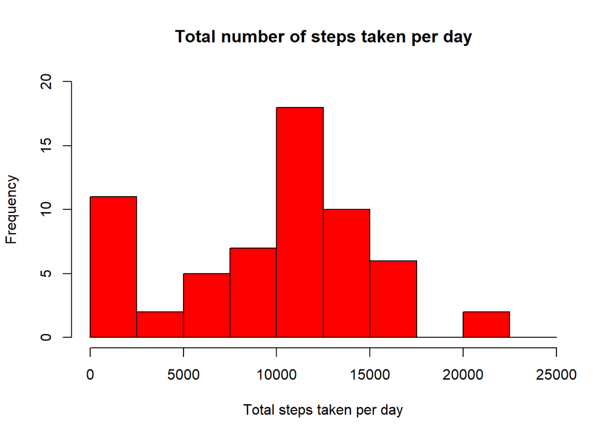

```r
activity.total.steps <- with(activity.data, aggregate(steps, by = list(date), FUN = sum, na.rm = TRUE))
names(activity.total.steps) <- c("date", "steps")
hist(activity.total.steps$steps, main = "Total number of steps taken per day", xlab = "Total steps taken per day", col = "red", ylim = c(0,20), breaks = seq(0,25000, by=2500))
```

*Q.3 Mean and median number of steps taken each day*

1.Mean of the steps taken each day

```r
mean(activity.total.steps$steps)
```

```
## [1] 9354.23
```

2.Median of the steps taken each day

```r
median(activity.total.steps$steps)
```

```
## [1] 10395
```

*Q.4 Time series plot of the average number of steps taken*

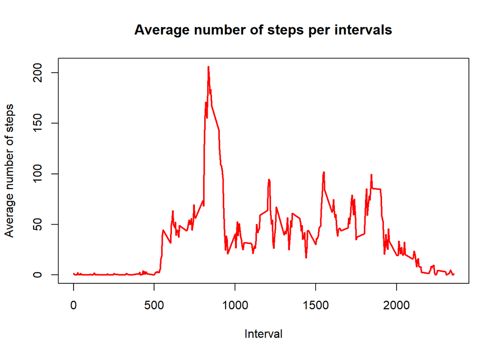

```r
average.daily.activity <- aggregate(activity.data$steps, by=list(activity.data$interval), FUN=mean, na.rm=TRUE)
names(average.daily.activity) <- c("interval", "mean")
plot(average.daily.activity$interval, average.daily.activity$mean, type = "l", col="red", lwd = 2, xlab="Interval", ylab="Average number of steps", main="Average number of steps per intervals")
```

*Q.5The 5-minute interval that, on average, contains the maximum number of steps*

```r
average.daily.activity[which.max(average.daily.activity$mean), ]$interval
```

```
## [1] 835
```

*Q.6 Code to describe and show a strategy for imputing missing data*

1.Calculating the total number of missing values in the dataset

```r
sum(is.na(activity.data$steps))
```

```
## [1] 2304
```

2.filling in all of the missing values in the dataset

```r
imputed.steps <- average.daily.activity$mean[match(activity.data$interval, average.daily.activity$interval)]
```

3.Creating a new dataset that is equal to the original dataset but with the missing data filled in.

```r
activity.imputed <- transform(activity.data, steps = ifelse(is.na(activity.data$steps), yes = imputed.steps, no = activity.data$steps))
total.steps.imputed <- aggregate(steps ~ date, activity.imputed, sum)
names(total.steps.imputed) <- c("date", "daily_steps")
```

*Q.7 Histogram of the total number of steps taken each day after missing values are imputed*

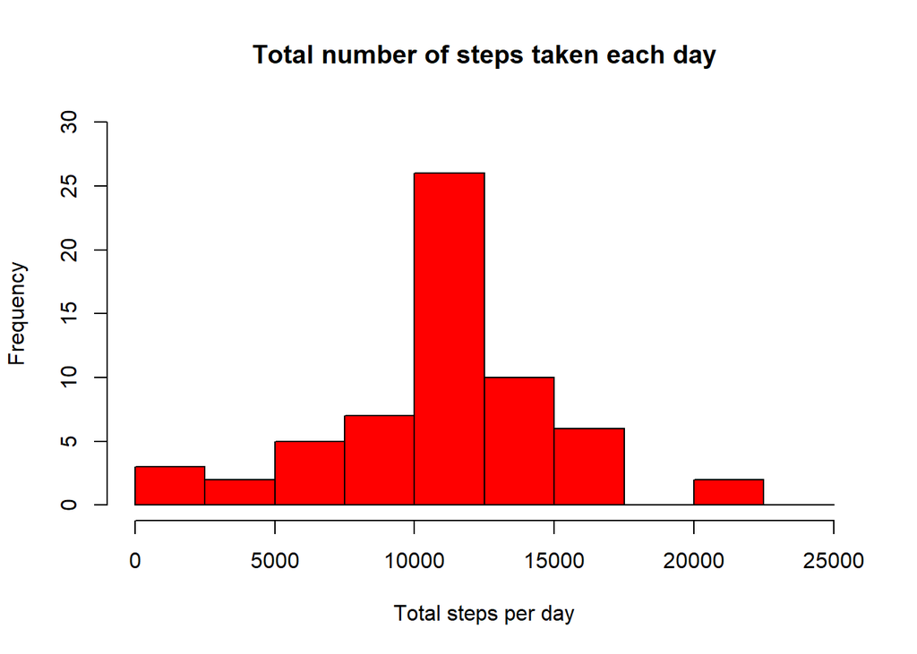

```r
hist(total.steps.imputed$daily_steps, col = "red", xlab = "Total steps per day", ylim = c(0,30), main = "Total number of steps taken each day", breaks = seq(0,25000,by=2500))
```

*Q.8 Panel plot comparing the average number of steps taken per 5-minute interval across weekdays and weekends*

1.Creating a new factor variable in the dataset with two levels – “weekday” and “weekend”

```r
activity.data$date <- as.Date(strptime(activity.data$date, format="%Y-%m-%d"))
activity.data$day <- weekdays(activity.data$date)
for (i in 1:nrow(activity.data)){
  if (activity.data[i,]$day %in% c("Saturday", "Sunday")){
    activity.data[i,]$day <- "weekend"
  }
  else {
    activity.data[i,]$day <- "weekday"
  }
}
```

Panel Plot

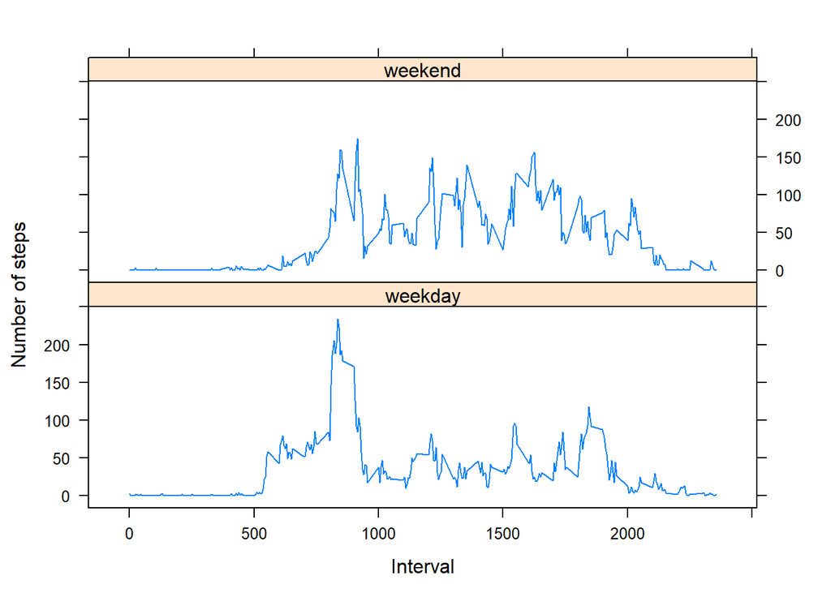

```r
steps.by.day <- aggregate(activity.data$steps ~ activity.data$interval + activity.data$day, activity.data, mean, na.rm = TRUE)
names(steps.by.day) <- c("interval", "day", "steps")
library(lattice)
xyplot(steps ~ interval | day, steps.by.day, type = "l", layout = c(1, 2), xlab = "Interval", ylab = "Number of steps")
```